# Riemannian STATS Example1: Iris Dataset

Jennifer Lobo Vásquez & Oldemar Rodríguez Rojas

# Riemannian Principal Component Analysis

This document demonstrates the use of the `riemannian_stats` package to perform **Riemannian Principal Component Analysis (R-PCA)** on the classical **Iris dataset**. R-PCA is a novel extension of standard PCA that leverages the local geometry of data using a Riemannian manifold structure induced via **UMAP**.

We showcase the full pipeline: loading and preprocessing the dataset, computing manifold-based metrics, extracting Riemannian principal components, and visualizing both the structure and correlation of the data.

## 📦 Load Required Modules

```python
from riemannian_stats import riemannian_analysis, visualization, data_processing, utilities
```

## 📄 Load and Prepare Data

```python
data = data_processing.load_data("./data/iris.csv", separator=";", decimal=".")
n_neighbors = int(len(data) / 3)

if 'tipo' in data.columns:
    clusters = data['tipo']
    data_with_clusters = data.copy()
    data = data.iloc[:, :-1]
else:
    clusters = None
    data_with_clusters = data
```

We load the Iris dataset with custom separator/decimal symbols. The `tipo` column is used as cluster label if present, and removed for analysis purposes.

## 🔍 Create Analysis Instance

```python
analysis = riemannian_analysis(data, n_neighbors=n_neighbors)
```

We initialize the Riemannian analysis intance, specifying the number of neighbors based on the dataset size.

## 📈 UMAP Similarities and Rho Matrix

```python
umap_similarities = analysis.umap_similarities
print("UMAP Similarities Matrix:\n", umap_similarities)
```

```
## UMAP Similarities Matrix:
##  [[0.         0.01766587 0.05554996 ... 0.         0.         0.        ]
##  [0.01766587 0.         0.37440622 ... 0.         0.         0.        ]
##  [0.05554996 0.37440622 0.         ... 0.         0.         0.        ]
##  ...
##  [0.         0.         0.         ... 0.         0.257874   0.10819354]
##  [0.         0.         0.         ... 0.257874   0.         0.12052599]
##  [0.         0.         0.         ... 0.10819354 0.12052599 0.        ]]
```

```python
rho = analysis.rho
print("Rho Matrix:\n", rho)
```

```
## Rho Matrix:
##  [[1.         0.98233414 0.94445    ... 1.         1.         1.        ]
##  [0.98233414 1.         0.6255938  ... 1.         1.         1.        ]
##  [0.94445    0.6255938  1.         ... 1.         1.         1.        ]
##  ...
##  [1.         1.         1.         ... 1.         0.742126   0.8918065 ]
##  [1.         1.         1.         ... 0.742126   1.         0.87947404]
##  [1.         1.         1.         ... 0.8918065  0.87947404 1.        ]]
```

UMAP similarities define local neighborhood structure. The rho matrix encodes local scaling for each point, forming the foundation of the Riemannian metric.

## 🔁 Vector Differences and UMAP-Based Distances

```python
riemannian_diff = analysis.riemannian_diff
print("Riemannian Vector Differences:\n", riemannian_diff)
```

```
## Riemannian Vector Differences:
##  [[[ 0.          0.          0.          0.        ]
##   [ 0.19646683  0.49116707  0.          0.        ]
##   [ 0.37778001  0.28333501  0.094445    0.        ]
##   ...
##   [-1.4         0.5        -3.8        -1.8       ]
##   [-1.1         0.1        -4.         -2.1       ]
##   [-0.8         0.5        -3.7        -1.6       ]]
##
##  [[-0.19646683 -0.49116707  0.          0.        ]
##   [ 0.          0.          0.          0.        ]
##   [ 0.12511876 -0.12511876  0.06255938  0.        ]
##   ...
##   [-1.6         0.         -3.8        -1.8       ]
##   [-1.3        -0.4        -4.         -2.1       ]
##   [-1.          0.         -3.7        -1.6       ]]
##
##  [[-0.37778001 -0.28333501 -0.094445    0.        ]
##   [-0.12511876  0.12511876 -0.06255938  0.        ]
##   [ 0.          0.          0.          0.        ]
##   ...
##   [-1.8         0.2        -3.9        -1.8       ]
##   [-1.5        -0.2        -4.1        -2.1       ]
##   [-1.2         0.2        -3.8        -1.6       ]]
##
##  ...
##
##  [[ 1.4        -0.5         3.8         1.8       ]
##   [ 1.6         0.          3.8         1.8       ]
##   [ 1.8        -0.2         3.9         1.8       ]
##   ...
##   [ 0.          0.          0.          0.        ]
##   [ 0.2226378  -0.2968504  -0.1484252  -0.2226378 ]
##   [ 0.53508389  0.          0.08918065  0.1783613 ]]
##
##  [[ 1.1        -0.1         4.          2.1       ]
##   [ 1.3         0.4         4.          2.1       ]
##   [ 1.5         0.2         4.1         2.1       ]
##   ...
##   [-0.2226378   0.2968504   0.1484252   0.2226378 ]
##   [ 0.          0.          0.          0.        ]
##   [ 0.26384221  0.35178962  0.26384221  0.43973702]]
##
##  [[ 0.8        -0.5         3.7         1.6       ]
##   [ 1.          0.          3.7         1.6       ]
##   [ 1.2        -0.2         3.8         1.6       ]
##   ...
##   [-0.53508389  0.         -0.08918065 -0.1783613 ]
##   [-0.26384221 -0.35178962 -0.26384221 -0.43973702]
##   [ 0.          0.          0.          0.        ]]]
```

```python
umap_distance_matrix = analysis.umap_distance_matrix
print("UMAP Distance Matrix:\n", umap_distance_matrix)
```

```
## UMAP Distance Matrix:
##  [[0.         0.52900312 0.48157691 ... 4.45982062 4.65080638 4.14004831]
##  [0.52900312 0.         0.18767813 ... 4.49888875 4.71805044 4.15331193]
##  [0.48157691 0.18767813 0.         ... 4.66154481 4.84871117 4.29883705]
##  ...
##  [4.45982062 4.49888875 4.66154481 ... 0.         0.45747718 0.57103477]
##  [4.65080638 4.71805044 4.84871117 ... 0.45747718 0.         0.67553683]
##  [4.14004831 4.15331193 4.29883705 ... 0.57103477 0.67553683 0.        ]]
```

We compute the Riemannian vector difference and UMAP-induced distances to quantify local geometrical deviation between samples.

## 📊 Correlation Matrix and Principal Components

```python
riemann_corr = analysis.riemannian_correlation_matrix()
print("Riemannian Correlation Matrix:\n", riemann_corr)
```

```
## Riemannian Correlation Matrix:
##  [[ 1.         -0.12818677  0.86553676  0.78974045]
##  [-0.12818677  1.         -0.44643239 -0.39361534]
##  [ 0.86553676 -0.44643239  1.          0.96096511]
##  [ 0.78974045 -0.39361534  0.96096511  1.        ]]
```

```python
riemann_components = analysis.riemannian_components_from_data_and_correlation(riemann_corr)
print("Riemannian Principal Components:\n", riemann_components)
```

```
## Riemannian Principal Components:
##  [[-2.63097358e+00 -5.26465635e-01 -2.31377990e-01  1.00902430e-02]
##  [-2.42220256e+00  6.39026525e-01 -3.69619363e-01  8.66049256e-02]
##  [-2.71312994e+00  3.12321472e-01 -8.14538421e-02  4.08231981e-03]
##  [-2.64472373e+00  5.70817575e-01 -4.41041657e-02 -9.00116698e-02]
##  [-2.76038267e+00 -6.90832808e-01 -8.38861258e-02 -5.33614916e-02]
##  [-2.47600196e+00 -1.54771985e+00 -6.09838268e-02 -1.11707930e-02]
##  [-2.80822531e+00 -7.45565981e-02  2.14340545e-01 -7.03377631e-02]
##  [-2.59467656e+00 -2.65940241e-01 -2.00846520e-01 -3.96228831e-02]
##  [-2.66845727e+00  1.09795624e+00 -3.49584529e-03 -5.62953317e-02]
##  [-2.52589481e+00  4.30556981e-01 -3.80506873e-01 -4.93079250e-02]
##  [-2.54462940e+00 -1.10269806e+00 -3.57588874e-01  1.07659036e-02]
##  [-2.68778864e+00 -1.69782018e-01 -2.28231860e-02 -1.52787744e-01]
##  [-2.55381618e+00  6.95140958e-01 -3.63611816e-01 -1.02593242e-02]
##  [-2.96319693e+00  9.46697617e-01  4.39463823e-02 -4.90767271e-02]
##  [-2.59090982e+00 -1.93336800e+00 -5.34785847e-01  1.94297281e-01]
##  [-2.68638074e+00 -2.75824718e+00 -2.19814297e-02  3.54682501e-02]
##  [-2.60443874e+00 -1.53960268e+00 -8.82566526e-02  1.66352661e-01]
##  [-2.56197060e+00 -5.33486312e-01 -1.51782973e-01  7.25624942e-02]
##  [-2.29037459e+00 -1.47451952e+00 -4.59275835e-01  5.85926878e-02]
##  [-2.73025678e+00 -1.17589839e+00  4.07031342e-02 -5.89975772e-02]
##  [-2.28001564e+00 -4.66373851e-01 -5.29620361e-01  9.18338459e-03]
##  [-2.59445534e+00 -9.69458138e-01  5.84088508e-02  3.25344099e-02]
##  [-3.13926199e+00 -4.86340614e-01  2.31251303e-01 -1.34060323e-02]
##  [-2.19404013e+00 -1.26693680e-01 -9.59169201e-02  1.22483878e-01]
##  [-2.59146105e+00 -1.75869893e-01 -2.36856659e-03 -2.85930334e-01]
##  [-2.29537354e+00  5.85874185e-01 -4.41585514e-01  3.22351973e-02]
##  [-2.42456140e+00 -2.82010885e-01 -3.48382796e-02  4.09407557e-02]
##  [-2.53625375e+00 -5.77588684e-01 -3.10162347e-01  1.01378242e-04]
##  [-2.50156449e+00 -3.62098463e-01 -3.78869853e-01  7.35419776e-02]
##  [-2.61680236e+00  3.06233597e-01 -6.09992227e-02 -1.29060271e-01]
##  [-2.48739326e+00  4.70600770e-01 -2.08491087e-01 -6.56085359e-02]
##  [-2.20622806e+00 -4.76356621e-01 -3.84066741e-01  2.22889614e-01]
##  [-3.00604748e+00 -1.85133358e+00 -1.84215625e-02 -2.36729289e-01]
##  [-2.84812025e+00 -2.21706717e+00 -1.40563143e-01 -5.57599141e-02]
##  [-2.52589481e+00  4.30556981e-01 -3.80506873e-01 -4.93079250e-02]
##  [-2.55740723e+00  1.67069493e-01 -3.45079739e-01  1.51639179e-01]
##  [-2.41264024e+00 -7.20811371e-01 -5.80606451e-01  1.92039101e-01]
##  [-2.52589481e+00  4.30556981e-01 -3.80506873e-01 -4.93079250e-02]
##  [-2.76736492e+00  8.86524601e-01  5.15752484e-02 -4.09742042e-02]
```

[output cut: 96 more lines]

```
##  [ 2.28908997e+00 -9.78409574e-01 -7.74540088e-01  2.75597579e-01]
##  [ 1.05380427e+00 -1.14181491e+00  7.16956988e-01 -3.77527775e-02]
##  [ 8.70683186e-01 -5.06372533e-01 -3.87017835e-02 -2.46634214e-01]
##  [ 4.27569541e-01 -7.61505076e-02  1.79520318e-01 -4.11373674e-02]
##  [ 1.35863611e+00 -7.70874055e-01 -2.34747758e-01  1.57123396e-01]
##  [ 1.50464218e+00 -6.97807154e-01  1.88878833e-01  1.86994425e-01]
##  [ 1.40031450e+00 -7.78827533e-01 -9.60123434e-02  4.15210488e-01]
##  [ 6.99283037e-01  6.39930591e-01  2.78287165e-01 -9.62702105e-02]
##  [ 1.52777896e+00 -9.59429038e-01  1.06025172e-01 -3.28815380e-03]
##  [ 1.47215744e+00 -1.13377898e+00  3.99070657e-01  1.46966341e-01]
##  [ 1.37400088e+00 -4.69208382e-01  2.01216901e-02  3.31105364e-01]
##  [ 1.11732031e+00  8.26612581e-01 -2.78931036e-01  1.77708771e-01]
##  [ 1.04177066e+00 -3.49958839e-01 -4.74582331e-02  7.49046130e-02]
##  [ 8.57972266e-01 -1.08164190e+00  7.09328122e-01 -4.58553003e-02]
##  [ 4.93417375e-01 -3.91215431e-02  2.98591060e-01 -2.10910627e-01]]
```

Principal components are derived from the Riemannian correlation matrix, capturing variance in the intrinsic geometry of the data.

## 🧮 Explained Inertia

```python
comp1, comp2 = 0, 1
inertia = utilities.pca_inertia_by_components(riemann_corr, comp1, comp2) * 100
print(f"Explained Inertia (PC1 & PC2): {inertia:.2f}%")
```

```
## Explained Inertia (PC1 & PC2): 95.38%
```

The explained inertia quantifies the proportion of Riemannian variance captured by the first two components.

## 🔗 Correlation Between Variables and Components

```python
correlations = analysis.riemannian_correlation_variables_components(riemann_components)
print("Correlations Variables vs Components:\n", correlations)
```

```
## Correlations Variables vs Components:
##            Component_1 Component_2
## feature_1    0.876449   -0.383029
## feature_2   -0.488327   -0.865365
## feature_3    0.992478   -0.033786
## feature_4     0.96051   -0.051085
```

We compute how strongly each original variable is correlated with the Riemannian principal components.

## 📊 Visualizations

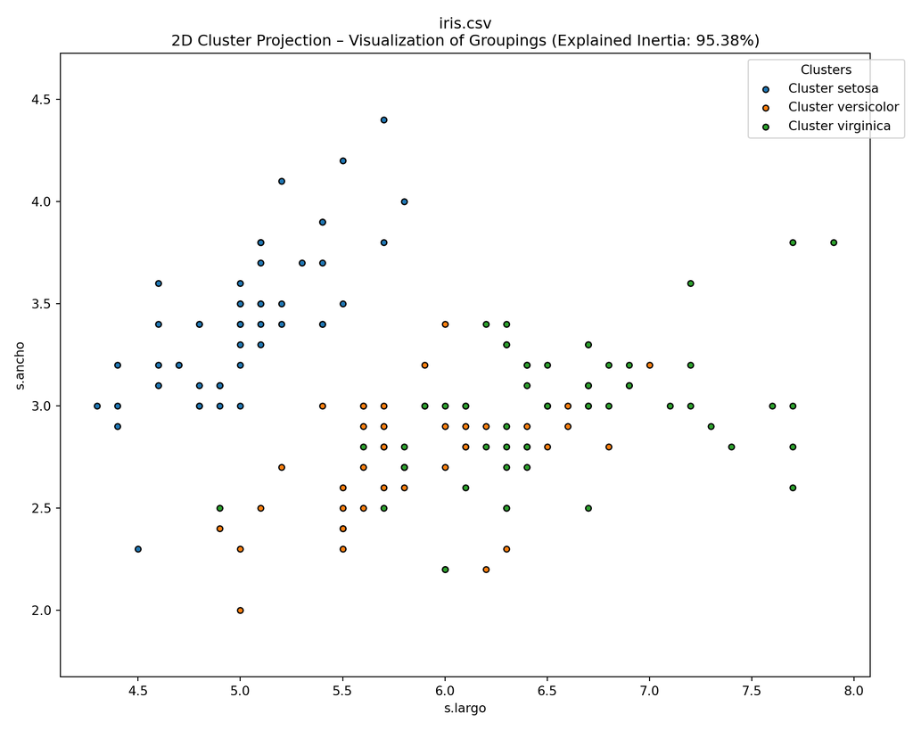

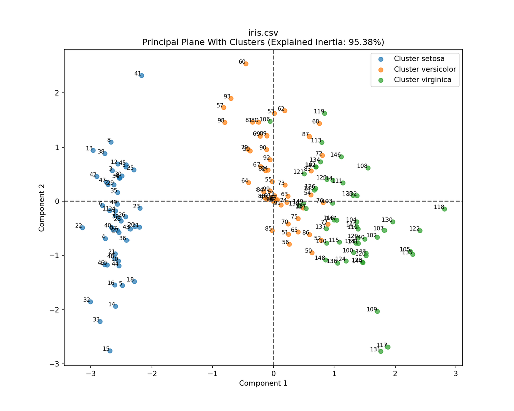

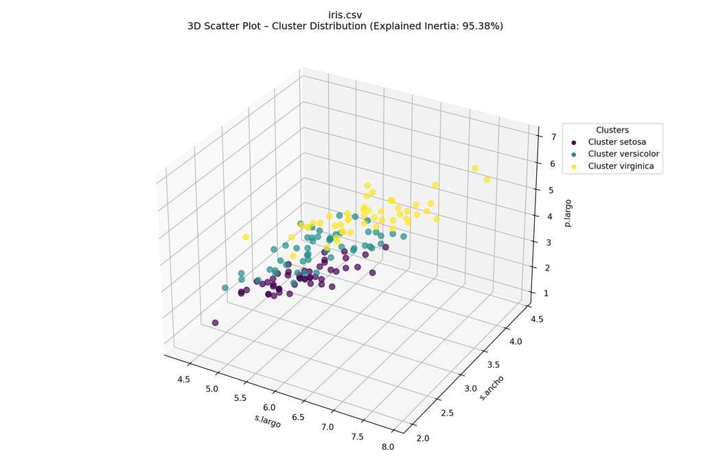

```python
if clusters is not None:
    viz = visualization(data=data_with_clusters,
                        components=riemann_components,
                        explained_inertia=inertia,
                        clusters=clusters)
    viz.plot_2d_scatter_with_clusters(x_col="s.largo", y_col="s.ancho", cluster_col="tipo", title="iris.csv")
    viz.plot_principal_plane_with_clusters(title="iris.csv")
    viz.plot_3d_scatter_with_clusters(x_col="s.largo", y_col="s.ancho", z_col="p.largo", cluster_col="tipo",
                                      title="iris.csv", figsize=(12, 8))
else:
    viz = visualization(data=data,
                        components=riemann_components,
                        explained_inertia=inertia)
    viz.plot_principal_plane(title="iris.csv")
```

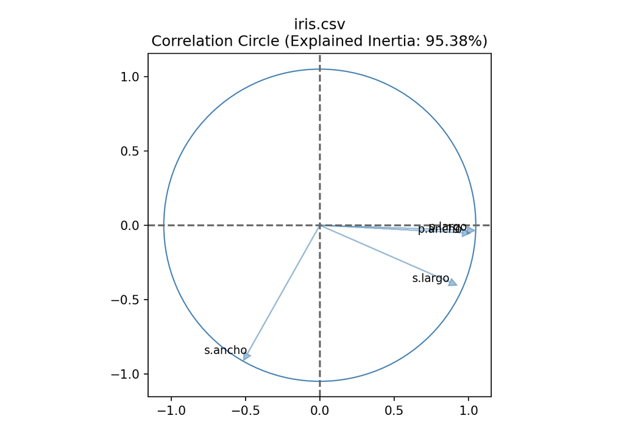

```python
viz.plot_correlation_circle(correlations=correlations, title="iris.csv")
```

## ✅ Summary

This analysis demonstrates how the **Riemannian STATS** package enables geometric analysis of tabular datasets by transforming Euclidean features into a **Riemannian manifold** via UMAP. The result is a more faithful low-dimensional representation that respects the dataset’s intrinsic structure.